# NYPD Analysis

2023-08-21

## Data Cleaning and Analysis

```r
#load required libraries
library(tidyverse)
library(skimr)
library(ggplot2)
library(caret)
```

```r
# File name
file_name = "NYPD_Shooting_Incident_Data__Historic_.csv"

data = read_csv(file_name)
# Generate a detailed summary
data_summary_detailed <- skim(data)

# Print the detailed summary
print(data_summary_detailed)
```

```
## ── Data Summary ────────────────────────
##                            Values
## Name                       data
## Number of rows             27312
## Number of columns          21
## _______________________
## Column type frequency:
##   character                12
##   difftime                 1
##   logical                  1
##   numeric                  7
## ________________________
## Group variables            None
##
## ── Variable type: character ────────────────────────────────────────────────────
##    skim_variable      n_missing complete_rate min max empty n_unique whitespace
##  1 OCCUR_DATE                 0        1       10  10     0     5761          0
##  2 BORO                       0        1        5  13     0        5          0
##  3 LOC_OF_OCCUR_DESC      25596        0.0628   6   7     0        2          0
##  4 LOC_CLASSFCTN_DESC     25596        0.0628   5  11     0        9          0
##  5 LOCATION_DESC          14977        0.452    3  25     0       40          0
##  6 PERP_AGE_GROUP          9344        0.658    3   7     0       10          0
##  7 PERP_SEX                9310        0.659    1   6     0        4          0
##  8 PERP_RACE               9310        0.659    5  30     0        8          0
##  9 VIC_AGE_GROUP              0        1        3   7     0        7          0
## 10 VIC_SEX                    0        1        1   1     0        3          0
## 11 VIC_RACE                   0        1        5  30     0        7          0
## 12 Lon_Lat                   10        1.00    24  45     0    12645          0
##
## ── Variable type: difftime ─────────────────────────────────────────────────────
##   skim_variable n_missing complete_rate min    max        median     n_unique
## 1 OCCUR_TIME            0             1 0 secs 86340 secs 54660 secs     1421
##
## ── Variable type: logical ──────────────────────────────────────────────────────
##   skim_variable           n_missing complete_rate  mean count
## 1 STATISTICAL_MURDER_FLAG         0             1 0.193 FAL: 22046, TRU: 5266
##
## ── Variable type: numeric ──────────────────────────────────────────────────────
##   skim_variable     n_missing complete_rate          mean            sd
## 1 INCIDENT_KEY              0          1    120860536.    73412859.
## 2 PRECINCT                  0          1           65.6         27.3
## 3 JURISDICTION_CODE         2          1.00         0.327        0.738
## 4 X_COORD_CD                0          1      1009449.       18378.
## 5 Y_COORD_CD                0          1       208127.       31886.
## 6 Latitude                 10          1.00        40.7          0.0875
## 7 Longitude                10          1.00       -73.9          0.0663
##          p0        p25        p50         p75        p100 hist
## 1 9953245   63860880   90372218.  188810230.  261190187   ▆▇▃▃▅
## 2       1         44         68          81         123   ▂▇▅▅▅
## 3       0          0          0           0           2   ▇▁▁▁▂
## 4  914928.   1000029.   1007731.    1016838     1066815.  ▁▁▇▇▂
## 5  125757.    182834.    194487.     239518.     271128.  ▁▇▇▆▆
## 6      40.5       40.7       40.7        40.8        40.9 ▁▇▇▆▆
## 7     -74.2      -73.9      -73.9       -73.9       -73.7 ▁▁▇▇▂
```

```r
for (col in c("LOCATION_DESC", "PERP_AGE_GROUP", "PERP_RACE", "PERP_SEX")) {
  unique_vals <- unique(data[[col]])
  print(paste("Unique values in", col, ":", toString(unique_vals)))
}
```

```
## [1] "Unique values in LOCATION_DESC : NA, MULTI DWELL - APT BUILD, MULTI DWELL - PUBLIC HOUS, GROCERY/BODEGA, JEWELRY STORE, CLOTHING BOUTIQUE, GAS STATION, BAR/NIGHT CLUB, PVT HOUSE, NONE, COMMERCIAL BLDG, SMALL MERCHANT, BEAUTY/NAIL SALON, FAST FOOD, DRUG STORE, TELECOMM. STORE, DRY CLEANER/LAU…
## [1] "Unique values in PERP_AGE_GROUP : NA, 25-44, UNKNOWN, 18-24, 45-64, <18, 65+, 940, (null), 224, 1020"
## [1] "Unique values in PERP_RACE : NA, BLACK, UNKNOWN, BLACK HISPANIC, ASIAN / PACIFIC ISLANDER, WHITE HISPANIC, WHITE, (null), AMERICAN INDIAN/ALASKAN NATIVE"
## [1] "Unique values in PERP_SEX : NA, M, U, F, (null)"
```

Since LOC_OF_OCCUR_DESC, LOC_CLASSFCTN_DESC columns complete rate is 0.0628, we are going to remove them

Also, for LOCATION_DESC, replace empty values with NONE,

For PERP_SEX replace empty values with U

We will also want to create a new column based on OCCUR_TIME column and then only choose columns that we want

```r
# Replace empty values in the LOCATION_DESC column with 'NONE'
data$LOCATION_DESC <- ifelse(is.na(data$LOCATION_DESC), 'NONE', data$LOCATION_DESC)

# Replace empty values in the PERP_AGE_GROUP column with 'UNKNOWN'
data$PERP_AGE_GROUP <- ifelse(is.na(data$PERP_AGE_GROUP), 'UNKNOWN', data$PERP_AGE_GROUP)
data$PERP_AGE_GROUP <- ifelse(data$PERP_AGE_GROUP == "(null)", 'UNKNOWN', data$PERP_AGE_GROUP)

# Replace empty values in the PERP_RACE column with 'UNKNOWN'
data$PERP_RACE <- ifelse(is.na(data$PERP_RACE), 'U', data$PERP_RACE)
data$PERP_RACE <- ifelse(data$PERP_RACE == '(null)', 'U', data$PERP_RACE)

# Replace empty values in the PERP_SEX column with 'U'
data$PERP_SEX <- ifelse(is.na(data$PERP_SEX), 'U', data$PERP_SEX)
data$PERP_SEX <- ifelse(data$PERP_SEX == '(null)', 'U', data$PERP_SEX)

# Create new column based on OCCUR_TIME column
data <- data %>%
  mutate(OCCUR_TIME_PERIOD = case_when(
    between(hour(OCCUR_TIME), 0, 6) ~ "Early Morning",
    between(hour(OCCUR_TIME), 6, 12) ~ "Morning",
    between(hour(OCCUR_TIME), 12, 18) ~ "Afternoon",
    TRUE ~ "Night"
  ))

# Choose columns that we want, also "X_COORD_CD", "Y_COORD_CD", "Latitude", "Longitude", "Lon_Lat" seem not to be useful, so I am not going to choose them too
selected_columns <- c("INCIDENT_KEY", "OCCUR_TIME_PERIOD", "BORO", "PRECINCT",
                      "LOCATION_DESC", "STATISTICAL_MURDER_FLAG",
                      "PERP_AGE_GROUP", "PERP_SEX", "PERP_RACE",
                      "VIC_AGE_GROUP", "VIC_SEX", "VIC_RACE")

data <- data %>%
  select(all_of(selected_columns))
```

We are then create a simple model which is logistic regression in this case

```r
# Select relevant columns for modeling
model_data <- data %>%
  select(BORO, OCCUR_TIME_PERIOD, STATISTICAL_MURDER_FLAG)

# Convert categorical variables to factors
model_data <- model_data %>%
  mutate_at(vars(BORO, OCCUR_TIME_PERIOD),
            factor)

# Split data into training and testing sets
set.seed(1)  # For reproducibility
train_index <- createDataPartition(model_data$STATISTICAL_MURDER_FLAG, p = 0.7, list = FALSE)
train_data <- model_data[train_index, ]
test_data <- model_data[-train_index, ]

# Build a logistic regression model
model <- glm(STATISTICAL_MURDER_FLAG ~ ., data = train_data, family = "binomial")

# Make predictions on the test set
predictions <- predict(model, newdata = test_data, type = "response")

# Convert predicted probabilities to binary predictions
predicted_labels <- ifelse(predictions > 0.5, 1, 0)

# Evaluate the model
confusion_matrix <- table(predicted_labels, test_data$STATISTICAL_MURDER_FLAG)
accuracy <- sum(diag(confusion_matrix)) / sum(confusion_matrix)

# Print model
summary(model)
```

```
##
## Call:
## glm(formula = STATISTICAL_MURDER_FLAG ~ ., family = "binomial",
##     data = train_data)
##
## Coefficients:
##                                  Estimate Std. Error z value Pr(>|z|)
## (Intercept)                    -1.3876408  0.0493479 -28.120  < 2e-16 ***
## BOROBROOKLYN                    0.0008071  0.0446137   0.018 0.985566
## BOROMANHATTAN                  -0.1570902  0.0631640  -2.487 0.012882 *
## BOROQUEENS                      0.0128623  0.0578981   0.222 0.824195
## BOROSTATEN ISLAND               0.1474376  0.1076836   1.369 0.170945
## OCCUR_TIME_PERIODEarly Morning -0.0763578  0.0502494  -1.520 0.128618
## OCCUR_TIME_PERIODMorning        0.2945357  0.0758626   3.882 0.000103 ***
## OCCUR_TIME_PERIODNight         -0.0718878  0.0506567  -1.419 0.155865
## ---
## Signif. codes:  0 '***' 0.001 '**' 0.01 '*' 0.05 '.' 0.1 ' ' 1
##
## (Dispersion parameter for binomial family taken to be 1)
##
##     Null deviance: 18749  on 19119  degrees of freedom
## Residual deviance: 18710  on 19112  degrees of freedom
## AIC: 18726
##
## Number of Fisher Scoring iterations: 4
```

```r
# Print the confusion matrix and accuracy
print(confusion_matrix)
```

```
##
## predicted_labels FALSE TRUE
##                0  6613 1579
```

```r
print(paste("Accuracy:", accuracy))
```

```
## [1] "Accuracy: 0.8072509765625"
```

The accuracy of the model is 0.8 which is not bad.

## Visualization

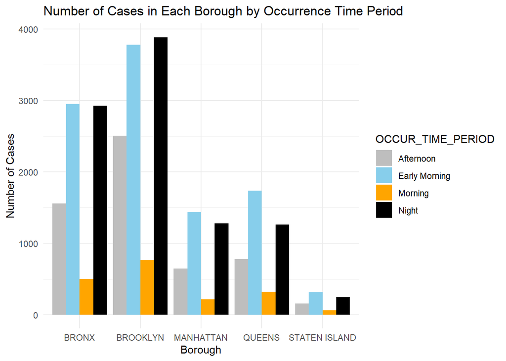

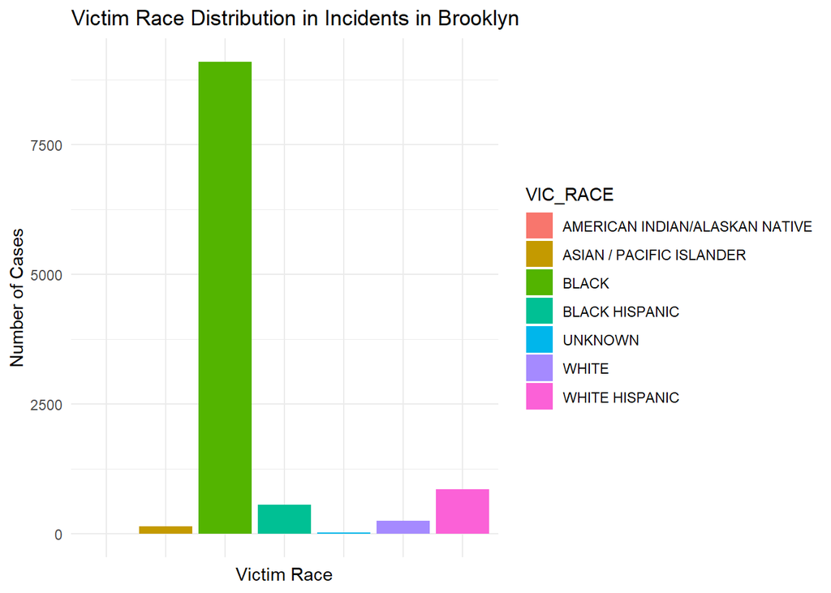

From the plot, we can see that most of the cases are in Brooklyn, and the victim race are mostly Black

Also these are a few bias that can affect our analysis:

Geographic Bias: If certain areas are over represented or underrepresented in the data, the analysis might not reflect the overall patterns accurately.

Missing Data Bias: If important variables are missing or incomplete, the analysis might be biased.